# Examples for word vector operation and WEAT code

Yuqing Jin 金昱清

2024-12-13

## 简介

本部分代码主要介绍如何使用”PsychoWord2Vec”R包实现基本的词向量线性运算以及Word Vector Association Test(WEAT)。主要分为以下部分：

1. 预训练词向量的下载及导入
2. 词向量的余弦相似度计算及可视化
3. WEAT代码及示例

**Reference：**  
Bao, H.-W.-S. (2022). PsychWordVec: Word embedding research framework for psychological science. https://CRAN.R-project.org/package=PsychWordVec

## 1. 预训练词向量的下载及导入

包寒吴霜老师为大家提供了常用的预训练静态词向量的.RData版本。  
下载地址：https://psychbruce.github.io/WordVector_RData.pdf

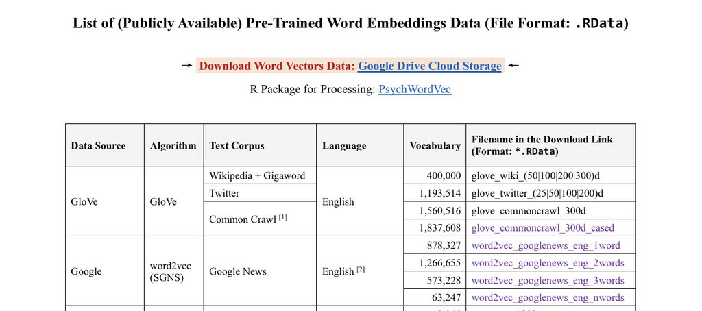

安装并加载必要的R包

```r
#Pacman
if (!requireNamespace('pacman', quietly = TRUE)) {
    install.packages('pacman')
}

#Core
pacman::p_load(PsychWordVec)

#General
pacman::p_load(bruceR,tidyverse)

#Specific
pacman::p_load(irr,nlme,knitr,ggrepel,zoo,see,cowplot,sjPlot)
```

导入Rdata文件

```r
Data_W2V = load_embed("../Data/Word2Vec/word2vec_googlenews_eng_1word.Rdata")
```

```
Loading...
```

```
✔ Word vectors data: 8000 vocab, 300 dims (time cost = 0.2 secs)
```

```
✔ All word vectors have been normalized to unit length 1.
```

```r
Data_W2V[1:10,1:10]
```

```
# embed (matrix): [10 × 10] (normalized)
```

```
            dim1 ...     dim10
 1: in    0.0530 ... <10 dims>
 2: for  -0.0085 ... <10 dims>
 3: that -0.0124 ... <10 dims>
 4: is    0.0037 ... <10 dims>
 5: on    0.0167 ... <10 dims>
 6: with -0.0160 ... <10 dims>
 7: said -0.0045 ... <10 dims>
 8: was   0.0126 ... <10 dims>
 9: the   0.0747 ... <10 dims>
10: at   -0.0354 ... <10 dims>
```

## 2. 余弦相似度计算及可视化

提取用于研究的特定词向量

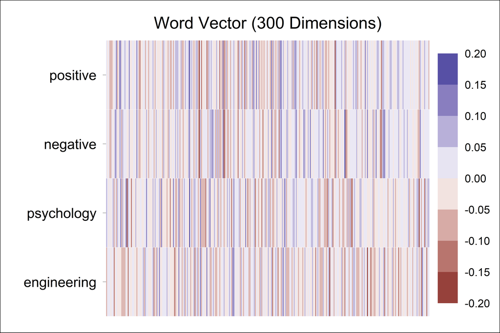

```r
#提取子集
rn <- c("positive","negative","psychology","engineering")
Data_W2V_sub <- Data_W2V[rn,]
remove(rn)

#画图
plot_wordvec(Data_W2V_sub)
```

余弦相似度的计算

```r
Data_W2V_sub <-  normalize(Data_W2V_sub)
cos_sim(Data_W2V_sub["positive",],Data_W2V_sub["negative",])
```

```
[1] 0.7587
```

也可以画相关图或网络分析图

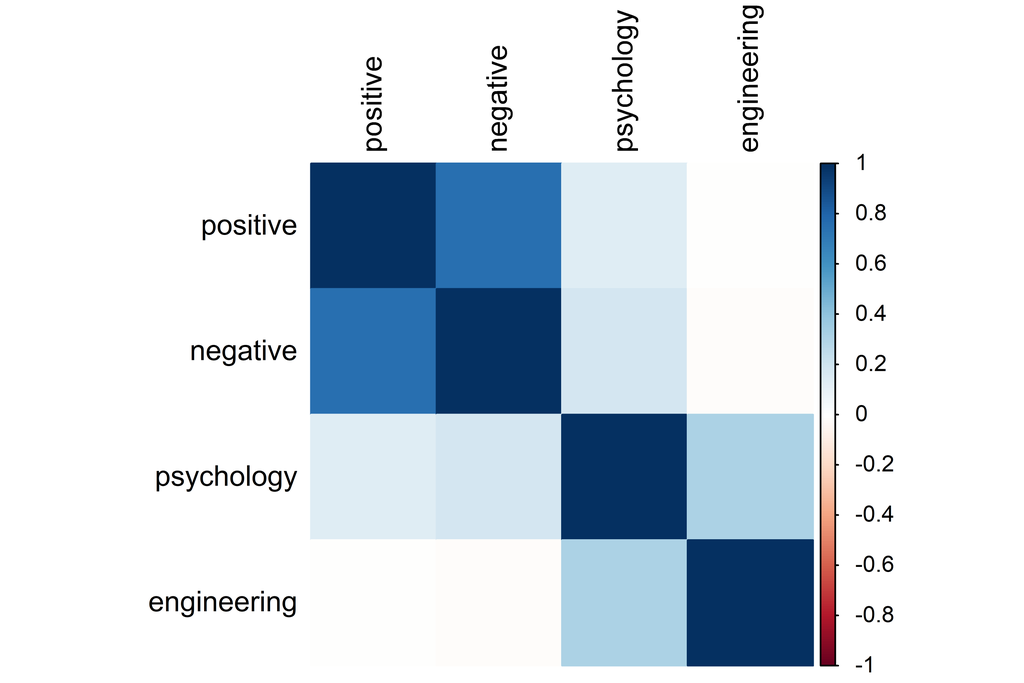

```r
plot_similarity(Data_W2V_sub)
```

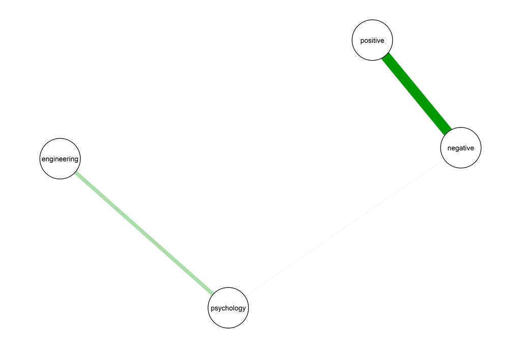

```r
plot_network(Data_W2V_sub)
```

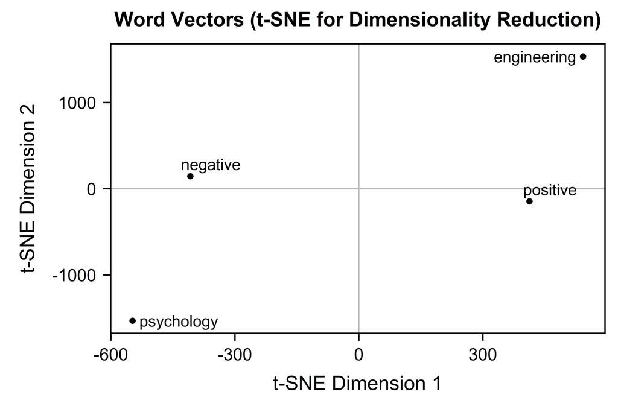

```r
plot_wordvec_tSNE(Data_W2V_sub)
```